# Survival Analysis in Breast Cancer patients

# Introduction

Breast Cancer is one of the most common cancer type worldwide. Depending on the type of cancer, age, or other biomarkers, the prognosis of a patient might vary.

In this project, we will explore th GBSG2 dataset, from the pec package. Thios dataset contains information of over 600 female patients who suffered Breast Cancer. The objetive is to develop a Survioval Analysis model that can explain which features are relevant and to which extent. In clinical practice, it is quite common to report Hazard Ratios, that can be estimated from Cox models.

The Cox proportional hazards model is a regression model that allows for comparing the effect of various variables on survival. It is such a widely used model because it accommodates multiple covariates, something especially important in clinical trials, where multidimensional datasets are typically involved. An HR value above 1 indicates that, if the value of the i-th covariate increases, the risk of the event occurring also increases, and therefore the survival curve will be reduced. Thus, the HR makes it possible to determine whether a covariate increases the risk of the event, reduces it, or, if its value is close to 1, indicates that it has no significant effect on that risk. For categorical value, this risk is compared to a reference (typically, one of the values of that categorical variable).

```r
library(pec)
library(DataExplorer)
library(summarytools)
library(ggplot2)
library(dplyr)
library(purrr)
library(tidyr)
library(patchwork)
library(corrplot)
library(survival)
library(survminer)
library(riskRegression)
library(rms)
library(broom)
library(randomForestSRC)
library(splines)
library(stringr)
library(forcats)
```

# EDA

You can include R code in the document as follows:

```r
data(GBSG2, package = "pec")
max(GBSG2$time) / 365 # years
```

```
## [1] 7.284932
```

```r
summary(GBSG2)
```

```
##  horTh          age        menostat       tsize        tgrade
##  no :440   Min.   :21.00   Post:396   Min.   :  3.00   I  : 81
##  yes:246   1st Qu.:46.00   Pre :290   1st Qu.: 20.00   II :444
##            Median :53.00              Median : 25.00   III:161
##            Mean   :53.05              Mean   : 29.33
##            3rd Qu.:61.00              3rd Qu.: 35.00
##            Max.   :80.00              Max.   :120.00
##      pnodes         progrec           estrec             time
##  Min.   : 1.00   Min.   :   0.0   Min.   :   0.00   Min.   :   8.0
##  1st Qu.: 1.00   1st Qu.:   7.0   1st Qu.:   8.00   1st Qu.: 567.8
##  Median : 3.00   Median :  32.5   Median :  36.00   Median :1084.0
##  Mean   : 5.01   Mean   : 110.0   Mean   :  96.25   Mean   :1124.5
##  3rd Qu.: 7.00   3rd Qu.: 131.8   3rd Qu.: 114.00   3rd Qu.:1684.8
##  Max.   :51.00   Max.   :2380.0   Max.   :1144.00   Max.   :2659.0
##       cens
##  Min.   :0.0000
##  1st Qu.:0.0000
##  Median :0.0000
##  Mean   :0.4359
##  3rd Qu.:1.0000
##  Max.   :1.0000
```

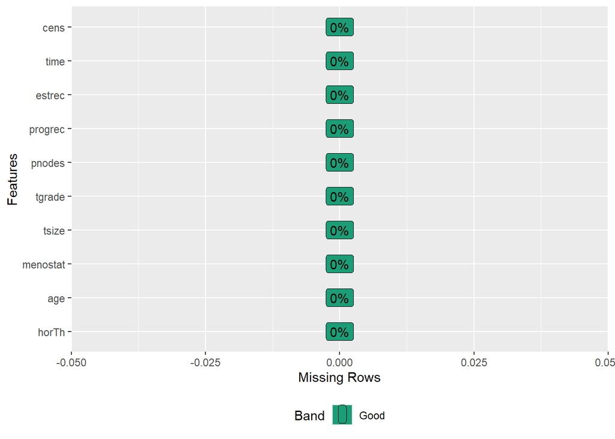

```r
# NAs?
plot_missing(GBSG2)
```

```r
# See structure
str(GBSG2)
```

```
## 'data.frame':    686 obs. of  10 variables:
##  $ horTh   : Factor w/ 2 levels "no","yes": 1 2 2 2 1 1 2 1 1 1 ...
##  $ age     : int  70 56 58 59 73 32 59 65 80 66 ...
##  $ menostat: Factor w/ 2 levels "Post","Pre": 1 1 1 1 1 2 1 1 1 1 ...
##  $ tsize   : int  21 12 35 17 35 57 8 16 39 18 ...
##  $ tgrade  : Factor w/ 3 levels "I","II","III": 2 2 2 2 2 3 2 2 2 2 ...
##  $ pnodes  : int  3 7 9 4 1 24 2 1 30 7 ...
##  $ progrec : int  48 61 52 60 26 0 181 192 0 0 ...
##  $ estrec  : int  66 77 271 29 65 13 0 25 59 3 ...
##  $ time    : int  1814 2018 712 1807 772 448 2172 2161 471 2014 ...
##  $ cens    : int  1 1 1 1 1 1 0 0 1 0 ...
```

```r
head(GBSG2)
```

|  | horTh | age | menostat | tsize | tgrade | pnodes | progrec | estrec | time | cens |
| --- | --- | --- | --- | --- | --- | --- | --- | --- | --- | --- |
| 1 | no | 70 | Post | 21 | II | 3 | 48 | 66 | 1814 | 1 |
| 2 | yes | 56 | Post | 12 | II | 7 | 61 | 77 | 2018 | 1 |
| 3 | yes | 58 | Post | 35 | II | 9 | 52 | 271 | 712 | 1 |
| 4 | yes | 59 | Post | 17 | II | 4 | 60 | 29 | 1807 | 1 |
| 5 | no | 73 | Post | 35 | II | 1 | 26 | 65 | 772 | 1 |
| 6 | no | 32 | Pre | 57 | III | 24 | 0 | 13 | 448 | 1 |

```r
print(dfSummary(GBSG2), method = "render")
```

Data Frame Summary

GBSG2

**Dimensions**: 686 x 10  
**Duplicates**: 0

| **No** | **Variable** | **Stats / Values** | **Freqs (% of Valid)** | **Graph** | **Valid** | **Missing** |
| --- | --- | --- | --- | --- | --- | --- |
| 1 | horTh [factor] | 1. no 2. yes | 440 ( 64.1% ) 246 ( 35.9% ) |  | 686 (100.0%) | 0 (0.0%) |
| 2 | age [integer] | Mean (sd) : 53.1 (10.1) min ≤ med ≤ max: 21 ≤ 53 ≤ 80 IQR (CV) : 15 (0.2) | 54 distinct values |  | 686 (100.0%) | 0 (0.0%) |
| 3 | menostat [factor] | 1. Post 2. Pre | 396 ( 57.7% ) 290 ( 42.3% ) |  | 686 (100.0%) | 0 (0.0%) |
| 4 | tsize [integer] | Mean (sd) : 29.3 (14.3) min ≤ med ≤ max: 3 ≤ 25 ≤ 120 IQR (CV) : 15 (0.5) | 58 distinct values |  | 686 (100.0%) | 0 (0.0%) |
| 5 | tgrade [factor] | 1. I 2. II 3. III | 81 ( 11.8% ) 444 ( 64.7% ) 161 ( 23.5% ) |  | 686 (100.0%) | 0 (0.0%) |
| 6 | pnodes [integer] | Mean (sd) : 5 (5.5) min ≤ med ≤ max: 1 ≤ 3 ≤ 51 IQR (CV) : 6 (1.1) | 30 distinct values |  | 686 (100.0%) | 0 (0.0%) |
| 7 | progrec [integer] | Mean (sd) : 110 (202.3) min ≤ med ≤ max: 0 ≤ 32.5 ≤ 2380 IQR (CV) : 124.8 (1.8) | 242 distinct values |  | 686 (100.0%) | 0 (0.0%) |
| 8 | estrec [integer] | Mean (sd) : 96.3 (153.1) min ≤ med ≤ max: 0 ≤ 36 ≤ 1144 IQR (CV) : 106 (1.6) | 244 distinct values |  | 686 (100.0%) | 0 (0.0%) |
| 9 | time [integer] | Mean (sd) : 1124.5 (642.8) min ≤ med ≤ max: 8 ≤ 1084 ≤ 2659 IQR (CV) : 1117 (0.6) | 574 distinct values |  | 686 (100.0%) | 0 (0.0%) |
| 10 | cens [integer] | Min : 0 Mean : 0.4 Max : 1 | 0 : 387 ( 56.4% ) 1 : 299 ( 43.6% ) |  | 686 (100.0%) | 0 (0.0%) |

Generated by summarytools 1.1.3 ([R](https://www.r-project.org/) version 4.4.3)  
2025-08-20

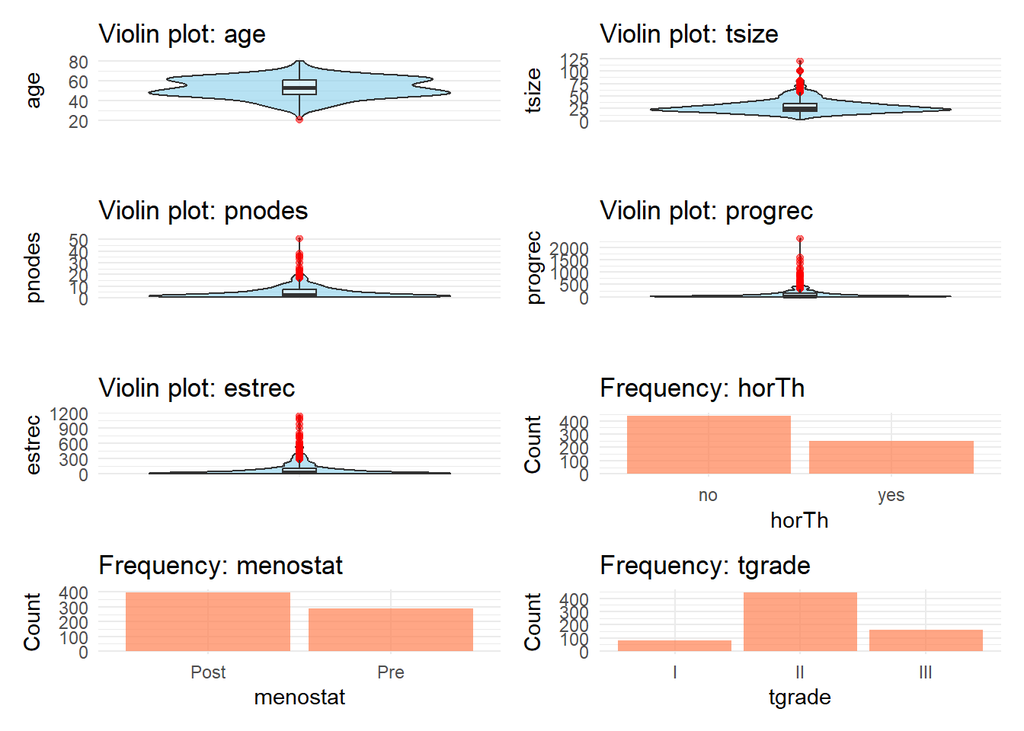

```r
# Violin plots / count plot
num_vars <- GBSG2 %>% select(where(is.numeric)) %>% names()
cat_vars <- GBSG2 %>% select(where(is.factor)) %>% names()
num_vars <- setdiff(num_vars, c("time","cens")) # Exclude status and T2E from graphs

plots_num <- map(num_vars, function(var) {
  ggplot(GBSG2, aes(x = "", y = .data[[var]])) +
    geom_violin(fill = "skyblue", alpha = 0.6) +
    geom_boxplot(width = 0.1, outlier.colour = "red", alpha = 0.5) +
    labs(title = paste("Violin plot:", var), y = var, x = "") +
    theme_minimal()
})

plots_cat <- map(cat_vars, function(var) {
  ggplot(GBSG2, aes(x = .data[[var]])) +
    geom_bar(fill = "coral", alpha = 0.7) +
    labs(title = paste("Frequency:", var), x = var, y = "Count") +
    theme_minimal()
})

all_plots <- c(plots_num, plots_cat)
wrap_plots(all_plots, ncol = 2)
```

We can see that the variables in this dataset cobntain the following features, with no missing values: - horTh: hormonal therapy, a factor with levels no yes - age: age in years - menostat: menopausal status, a factor with levels Pre Post - tsize: tumor size (in mm) - tgrade: an ordered factor with levels I < II < III - pnodes: number of positive nodes - progrec: progesterone receptor (in fmol). - estrec: estrogen receptor (in fmol). - time: recurrence free survival time (in days). - cens: censoring indicator (0- censored, 1- event).

We see that progrec and estrec variables are quite skewed, it might be interesting to convert them to a log scale. Some patients have values of 0, so we have to take that into account when transforming the variable

```r
# Transform variables
GBSG2$log_estrec  <- log1p(GBSG2$estrec)   # log(1+ER)
GBSG2$log_progrec <- log1p(GBSG2$progrec)  # log(1+PR)
```

Let’s now check if there is any high correlation in the dataset:

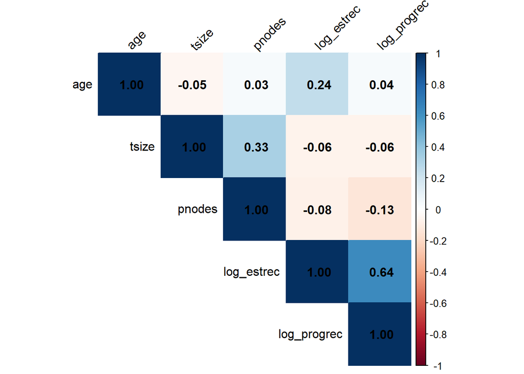

```r
# Correlation map (Pearson)
num_data <- GBSG2 %>%
  select(where(is.numeric)) %>%
  select(-time, -cens, -progrec, -estrec)

corr_matrix <- cor(num_data, use = "complete.obs")

# Plot
corrplot(corr_matrix, method = "color", type = "upper",
         addCoef.col = "black",
         tl.col = "black", tl.srt = 45)
```

There might be some correlation with PR and ER receptors, but I believe is nothing too worrying (<0.7). I expect that ER-/PR- patients have 0 values for both, displaying a high correlaction.

# Kaplan-Meier curves

Kaplan-Meier (KM) estimator is an univariate, yet useful, technique, to understand survival. Let’s check the overall survival of the patients in the study, as well as these patients stratified by some variables, such as menopausal status, tumour stage or if they have received hormonal treatment.

The statistical test that allows the comparaison between different curves is the Log-rank test. The null hypothesis of this tests is that the survival curves as estimated with the KM method are equal. In the following graphs, if the p-value is significant, then we can assume that the survival curves are different.

[figure not shown]

As we can see from these plots, it seems like the menopausal status of the patient does not impact overall survival. On the other hand, we can see that patients that underwent hormone treatmente haver a better prognostic, although this might not be true for PR-/ER- patients. Also, there is a significant difference of overall survival for patients with a stage 1 tumour, compared to patients with stage 2 or 3. Overall survival for patients with a stage 2 tumoursseem to be better at early stages, however, as time goes by, the overall survival is similar to stage 3 patients.

# Cox model

As commented earlier, Cox models are able to accommodate several variables, being a multivariate model. This allows to take into consideration multiple features at once, either as confounding variables or relevant outcomes for clinical interpretation. This model makes a fundamental assumption, namely that the risk of experiencing the event between two groups is proportional over time, so whenever we build the model, it is crucial to check this assumption so we make sure our model is roobust enough and oyur results are interpretable. This is the Proportional Hazards (PH) assumption.

Let’s start by building our reference model!

```r
cox0 <- coxph(
  surv_obj ~ age + menostat + tsize + tgrade + pnodes +
    log_progrec + log_estrec + horTh, data = GBSG2
)
```

We can assess the proportional hazards (PH) assumption by examining the Schoenfeld residuals plotted against transformed time. Very small p-values suggest the presence of time-dependent coefficients that need to be addressed. Importantly, the proportionality assumption does not test for linearity—since the Cox PH model is semi-parametric, it does not impose a specific form on the hazard function. Instead, the assumption concerns whether an individual’s hazard ratio remains relatively constant over time, which is precisely what the `cox.zph()` test evaluates.

```r
zph <- cox.zph(cox0, transform = "km")
zph
```

```
##              chisq df       p
## age         11.058  1 0.00088
## menostat     5.502  1 0.01899
## tsize        0.224  1 0.63577
## tgrade      10.355  2 0.00564
## pnodes       0.700  1 0.40271
## log_progrec  6.371  1 0.01160
## log_estrec  12.745  1 0.00036
## horTh        0.178  1 0.67293
## GLOBAL      25.832  9 0.00218
```

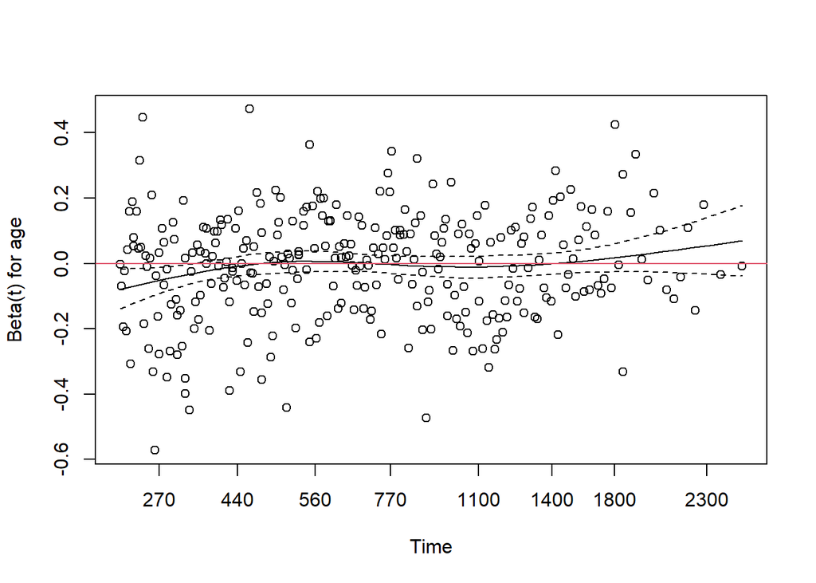

```r
plot(zph, var = 1) # age
abline(h = 0, col =2)
```

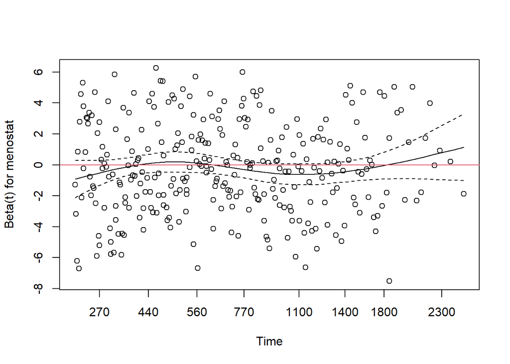

```r
plot(zph, var = 2) # menostat
abline(h = 0, col =2)
```

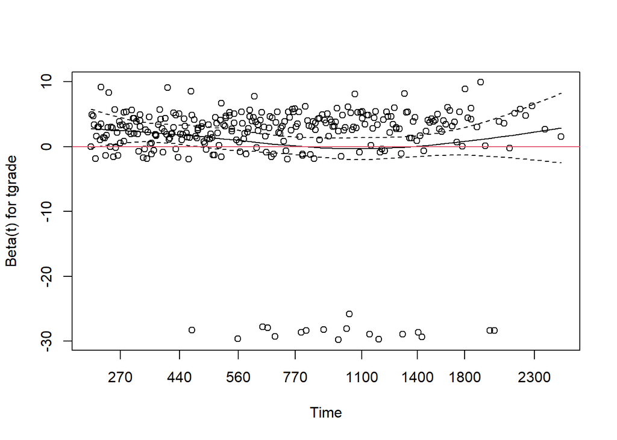

```r
plot(zph, var = 4) # tgrade
abline(h = 0, col =2)
```

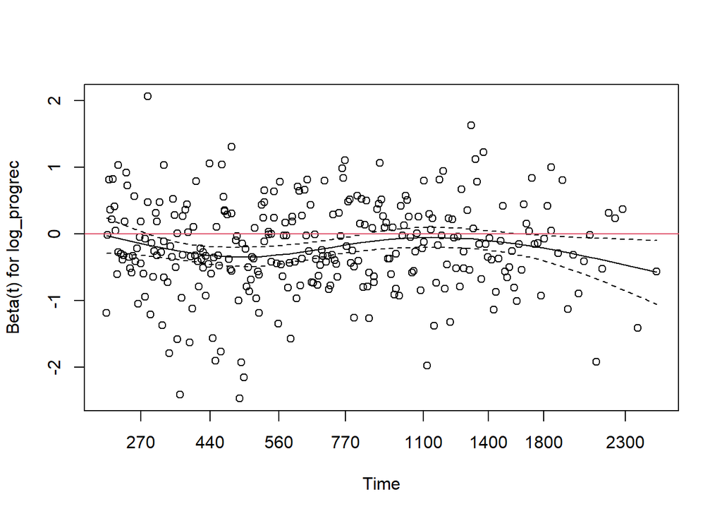

```r
plot(zph, var = 6) # progrec
abline(h = 0, col =2)
```

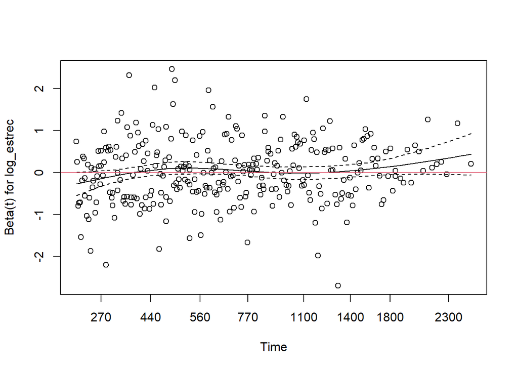

```r
plot(zph, var = 7) # estrec
abline(h = 0, col =2)
```

As we can see in the test, there are a few significant variables, indicating that these variables are not following the PH assumption. We can plot the Schoenfeld residuals (check https://stats.stackexchange.com/questions/547078/schoenfeld-residuals-plain-english-explanation-please) against time. I’ve plotted those variables where we suspect there is violation of thee assumption. If these variables were constant over time (i.e. following the PH assumption), we would see a straight line near 0. However, we see that the smoothed line in these cases is not really a straigt line near 0.

This assumption is violated in most datasets I’ve worked with. Therer are several ways of overcoming this issue: stratifying data, creating a Cox extended model with Time Dependent variables or by creating step-functions and splitting time spans, so we couldn have different HRs for different time-splits.

Let’s check how stratification would work. For this, we need a factor variable (what we will be doing in this example) or by stratifying a continous variable. This latter example might be interesting in some scenarios (i.e. high levels, medium levels and highh levels) and provide great interpretability to the model. In this case, we will stratify by tumour stage and menstrual status. Before creating this strata, it is important to check if we have enough data in all groups

```r
table(GBSG2$menostat, GBSG2$tgrade)
```

```
##
##          I  II III
##   Post  48 261  87
##   Pre   33 183  74
```

```r
with(GBSG2, table(menostat, tgrade, cens))
```

```
## , , cens = 0
##
##         tgrade
## menostat   I  II III
##     Post  36 137  43
##     Pre   27 105  39
##
## , , cens = 1
##
##         tgrade
## menostat   I  II III
##     Post  12 124  44
##     Pre    6  78  35
```

We see that we have event information on every strata, so we are good to go!

```r
cox1 <- coxph(
  surv_obj ~ age + tsize + pnodes + log_progrec + log_estrec + horTh +
    strata(menostat, tgrade),
  data = GBSG2,
  x = TRUE, y = TRUE
)

summary(cox1)
```

```
## Call:
## coxph(formula = surv_obj ~ age + tsize + pnodes + log_progrec +
##     log_estrec + horTh + strata(menostat, tgrade), data = GBSG2,
##     x = TRUE, y = TRUE)
##
##   n= 686, number of events= 299
##
##                  coef exp(coef)  se(coef)      z Pr(>|z|)
## age         -0.008738  0.991300  0.009209 -0.949  0.34271
## tsize        0.006524  1.006545  0.004007  1.628  0.10347
## pnodes       0.050624  1.051927  0.007845  6.453 1.09e-10 ***
## log_progrec -0.192398  0.824979  0.041113 -4.680 2.87e-06 ***
## log_estrec   0.025453  1.025780  0.042509  0.599  0.54933
## horThyes    -0.365690  0.693718  0.130020 -2.813  0.00491 **
## ---
## Signif. codes:  0 '***' 0.001 '**' 0.01 '*' 0.05 '.' 0.1 ' ' 1
##
##             exp(coef) exp(-coef) lower .95 upper .95
## age            0.9913     1.0088    0.9736    1.0094
## tsize          1.0065     0.9935    0.9987    1.0145
## pnodes         1.0519     0.9506    1.0359    1.0682
## log_progrec    0.8250     1.2122    0.7611    0.8942
## log_estrec     1.0258     0.9749    0.9438    1.1149
## horThyes       0.6937     1.4415    0.5377    0.8951
##
## Concordance= 0.679  (se = 0.017 )
## Likelihood ratio test= 87.07  on 6 df,   p=<2e-16
## Wald test            = 101.4  on 6 df,   p=<2e-16
## Score (logrank) test = 106  on 6 df,   p=<2e-16
```

```r
zph_strat <- cox.zph(cox1, transform = "km")
zph_strat
```

```
##               chisq df     p
## age         4.16194  1 0.041
## tsize       0.00294  1 0.957
## pnodes      0.71959  1 0.396
## log_progrec 2.84419  1 0.092
## log_estrec  5.47562  1 0.019
## horTh       0.13748  1 0.711
## GLOBAL      9.12561  6 0.167
```

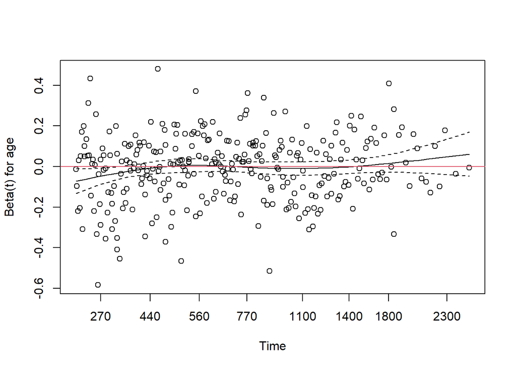

```r
plot(zph_strat, var = 1)
abline(h = 0, col = 2)
```

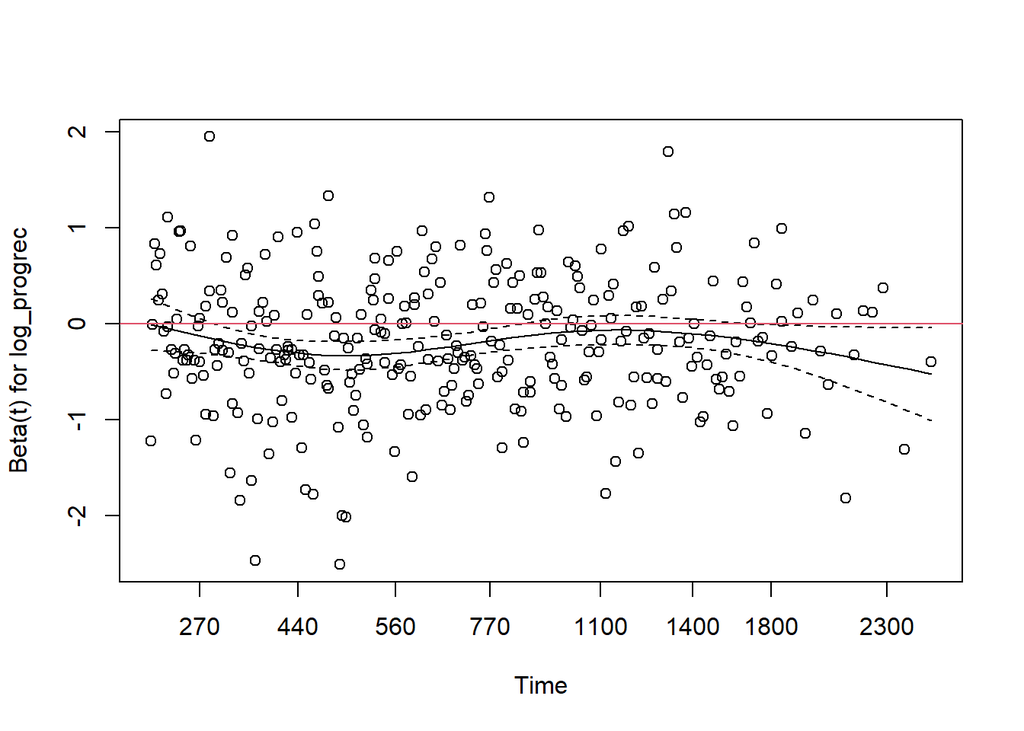

```r
plot(zph_strat, var = 4)
abline(h = 0, col = 2)
```

```r
# Define data cuts
cuts <- c(0, 365*2.5, 365*5, Inf)

gb <- survSplit(GBSG2, cut = cuts[-c(1, length(cuts))],
                end = "time", start = "tstart", event = "cens",
                episode = "split")


cox2 <- coxph(
  Surv(tstart, time, cens) ~ tsize + pnodes + horTh + log_estrec +
    strata(menostat, tgrade) +
    age:strata(split) + log_progrec:strata(split),
  data = gb, x = TRUE, y = TRUE
)

cox.zph(cox2)
```

```
##                             chisq df     p
## tsize                      0.0298  1 0.863
## pnodes                     0.6664  1 0.414
## horTh                      0.0570  1 0.811
## log_estrec                 3.6195  1 0.057
## age:strata(split)         10.8016  3 0.013
## strata(split):log_progrec  1.5637  3 0.668
## GLOBAL                    15.1529 10 0.127
```

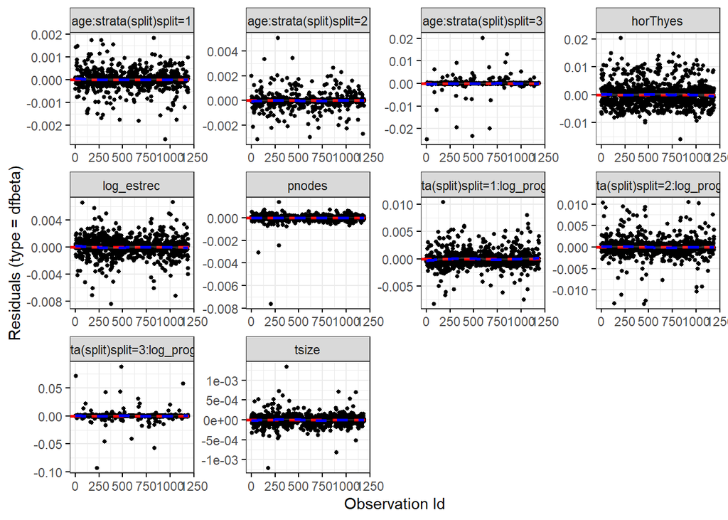

```r
# --- Influential observations ---------------------------------------------
ggcoxdiagnostics(cox2, type = "dfbeta", linear.predictions = FALSE)
```

Although we can observe a few observations, it seems like they do not have a big impact on the model.

Now that we have already built the model, let’s take a look at the results!

```r
summary(cox2)
```

```
## Call:
## coxph(formula = Surv(tstart, time, cens) ~ tsize + pnodes + horTh +
##     log_estrec + strata(menostat, tgrade) + age:strata(split) +
##     log_progrec:strata(split), data = gb, x = TRUE, y = TRUE)
##
##   n= 1192, number of events= 299
##
##                                       coef exp(coef)  se(coef)      z Pr(>|z|)
## tsize                             0.006679  1.006702  0.004011  1.665  0.09587
## pnodes                            0.050678  1.051984  0.007910  6.407 1.48e-10
## horThyes                         -0.354093  0.701810  0.130015 -2.723  0.00646
## log_estrec                        0.023985  1.024275  0.042519  0.564  0.57268
## age:strata(split)split=1         -0.010354  0.989699  0.011108 -0.932  0.35126
## age:strata(split)split=2         -0.014772  0.985337  0.017100 -0.864  0.38766
## age:strata(split)split=3          0.084765  1.088462  0.061307  1.383  0.16677
## strata(split)split=1:log_progrec -0.219381  0.803015  0.046449 -4.723 2.32e-06
## strata(split)split=2:log_progrec -0.118276  0.888451  0.067157 -1.761  0.07821
## strata(split)split=3:log_progrec -0.339125  0.712393  0.210128 -1.614  0.10655
##
## tsize                            .
## pnodes                           ***
## horThyes                         **
## log_estrec
## age:strata(split)split=1
## age:strata(split)split=2
## age:strata(split)split=3
## strata(split)split=1:log_progrec ***
## strata(split)split=2:log_progrec .
## strata(split)split=3:log_progrec
## ---
## Signif. codes:  0 '***' 0.001 '**' 0.01 '*' 0.05 '.' 0.1 ' ' 1
##
##                                  exp(coef) exp(-coef) lower .95 upper .95
## tsize                               1.0067     0.9933    0.9988    1.0146
## pnodes                              1.0520     0.9506    1.0358    1.0684
## horThyes                            0.7018     1.4249    0.5439    0.9055
## log_estrec                          1.0243     0.9763    0.9424    1.1133
## age:strata(split)split=1            0.9897     1.0104    0.9684    1.0115
## age:strata(split)split=2            0.9853     1.0149    0.9529    1.0189
## age:strata(split)split=3            1.0885     0.9187    0.9652    1.2274
## strata(split)split=1:log_progrec    0.8030     1.2453    0.7331    0.8796
## strata(split)split=2:log_progrec    0.8885     1.1256    0.7789    1.0134
## strata(split)split=3:log_progrec    0.7124     1.4037    0.4719    1.0754
##
## Concordance= 0.68  (se = 0.017 )
## Likelihood ratio test= 91.54  on 10 df,   p=3e-15
## Wald test            = 104.7  on 10 df,   p=<2e-16
## Score (logrank) test = 109.8  on 10 df,   p=<2e-16
```

Interestingly, it seems like we have a few significant variables, that are indeed influencing the survival time of the patients, such as the number of nodes, whether or not they have received hormonal thearapy. It seems like, in the first 2.5 years of the study,the levels of PR receptor seem to be relevant for patient survival.

Let’s try to plot these values, so it will be easier to understand what then model is inferring:

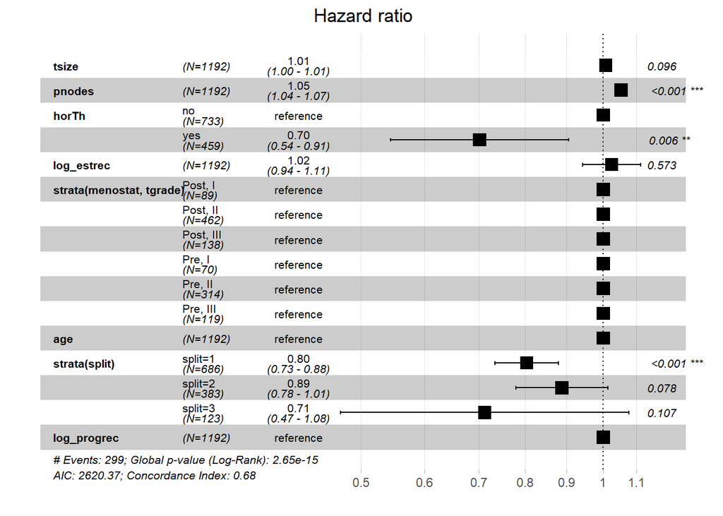

```r
ggforest(cox2, data = model.frame(cox2))
```

As commented earlier, we see that receiving hormone therapy decreses the risk of death, with a HR of 0.7, compared to not receiving this thearpy. This completely makes sense. If you receive hormone therapy, it is more likely you survive, although thisd has to be dependent on PR/ER levels. It might be interesting to create a different study for ER-/PR- patients and the rest!

Also, for the number of nodes, we can see a HR of 1.05. This means that, as the number of positive nodes increases, so does the hazard of faiolure (death). It might be interesting of assessing whether or not this is clinically significant!

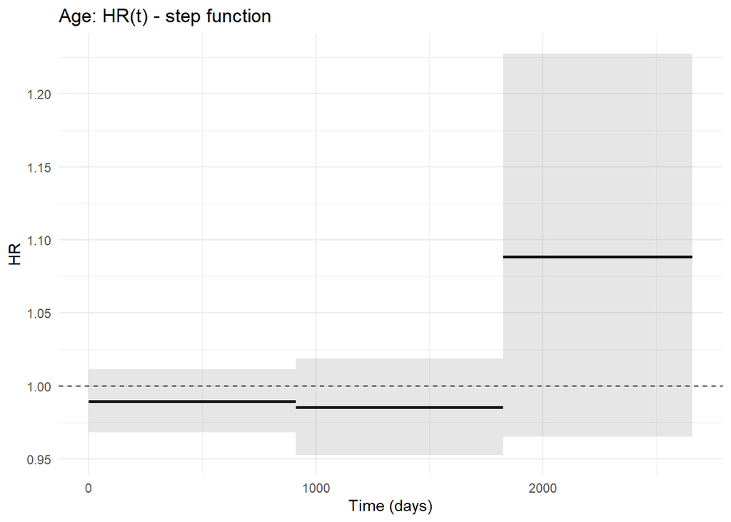

```r
# Does not display the change in HRs over time!
tt <- tidy(cox2, conf.int = TRUE, exponentiate = TRUE)
# age per split "age:strata(split)split=1"
age_df <- tt %>%
  filter(str_detect(term, "^age:strata\\(split\\)split=")) %>%
  mutate(
    split = as.integer(str_replace(term, "^age:strata\\(split\\)split=", "")),
    var   = "age"
  ) %>%
  select(var, split, estimate, conf.low, conf.high, p.value)

# log_progrec per split
pr_df <- tt %>%
  filter(str_detect(term, "log_progrec"),
         str_detect(term, "strata\\(split\\)split=")) %>%
  mutate(
    split = as.integer(str_extract(term, "(?<=split=)\\d+")),
    var   = "log_progrec"
  ) %>%
  select(var, split, estimate, conf.low, conf.high, p.value)

# Tags for intervals
bounds <- gb %>%
  group_by(split) %>%
  summarise(
    t_start = min(tstart, na.rm = TRUE),
    t_end   = max(time,   na.rm = TRUE),
    .groups = "drop"
  ) %>%
  arrange(split) %>%
  mutate(
    int_lab = paste0("[", t_start, ", ", t_end, "] días")
  )

age_df  <- age_df  %>% left_join(bounds, by = "split")
pr_df   <- pr_df   %>% left_join(bounds, by = "split")

age_df$int_lab <- fct_inorder(age_df$int_lab)
pr_df$int_lab  <- fct_inorder(pr_df$int_lab)

# Plot

g_age_step <- ggplot(age_df, aes(x = t_start, xend = t_end,
                                 y = estimate, yend = estimate)) +
  geom_hline(yintercept = 1, linetype = 2) +
  geom_segment(linewidth = 1) +
  geom_rect(aes(xmin = t_start, xmax = t_end,
                ymin = conf.low, ymax = conf.high),
            alpha = 0.15) +
  labs(x = "Time (days)", y = "HR",
       title = "Age: HR(t) - step function") +
  theme_minimal()

g_pr_step <- ggplot(pr_df, aes(x = t_start, xend = t_end,
                               y = estimate, yend = estimate)) +
  geom_hline(yintercept = 1, linetype = 2) +
  geom_segment(linewidth = 1) +
  geom_rect(aes(xmin = t_start, xmax = t_end,
                ymin = conf.low, ymax = conf.high),
            alpha = 0.15) +
  labs(x = "Time (days)", y = "HR",
       title = "log_progrec: HR(t) - step function") +
  theme_minimal()

g_age_step
```

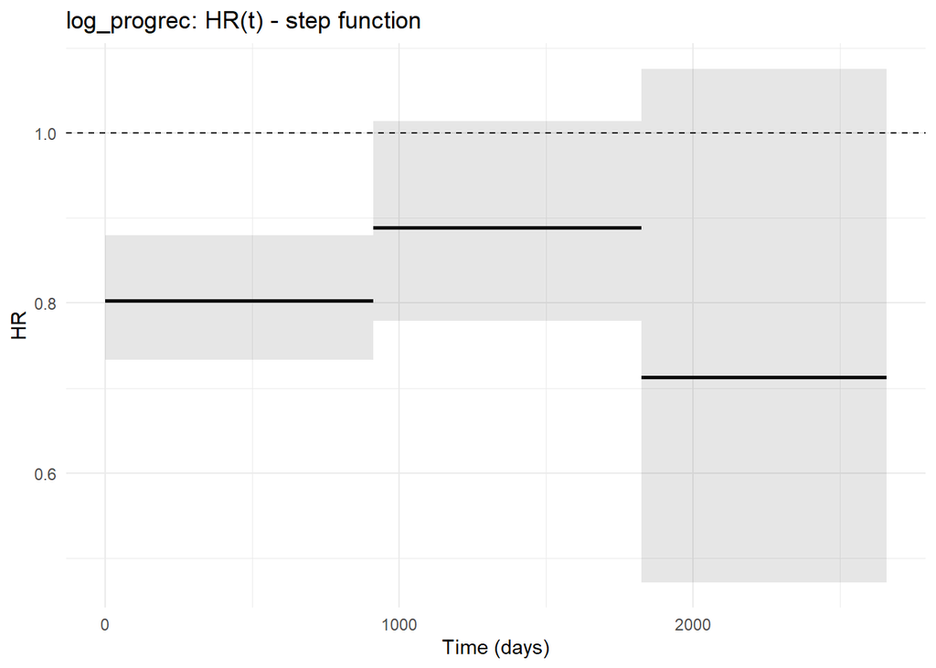

```r
g_pr_step
```

We can see that, on early days of the study, the HR for log_progrec is 0.8, meaning that high levels of the receptor correwlate with a better prognosis. However, this does not seem to be true after 2.5 years. In terms of age, it does not seem to be significant at all. For future models, it might be interesting to model age as a Predictable time-dependent covariates (check https://cran.r-project.org/web/packages/survival/vignettes/timedep.pdf)